# Selection Scenario simulation for Dogs in AlphaSimR

2024-04-22

# 0: Preparation

## Defining the output directory & the chromosome to be simulated

```r
# Clean the working environment
rm(list = ls())

knitr::opts_chunk$set(echo = TRUE)



####################################
# Defining the working directory
####################################

# Set the path to your GitHub folder
YOUR_GITHUB_ROOT_DIRECTORY <- "C:/Users/jonat/GitHub"

# Defining the relative path in the repository
repository_path <- "Computational-modelling-of-genomic-inbreeding-and-roh-islands-in-extremely-small-populations"

output_dir_simulation <- file.path(YOUR_GITHUB_ROOT_DIRECTORY, repository_path,"data/raw/simulated/selection_model")


if (!dir.exists(output_dir_simulation)) {
  # Create the working directory if it doesn't exist
  dir.create(output_dir_simulation)
}

# Set the working directory for notebook chunks
knitr::opts_knit$set(root.dir = output_dir_simulation)

####################################
# Defining Input parameters
####################################
min_MAF <- 0.05 #(minimum allowed Minor Allele Frequency for each SNP)
n_selection_sim_generations <- 300 # 500 default
allele_copies_threshold <- 10 # 10 default (candidate_variants = less than 10)
s <- 0.05 # Selection coefficient - 0.05 default
n_ind_per_selection_sim_generation <- 100 # 1000 default

####################################
# Defining the output files
####################################


# Define the chromosome to be simulated
chr_simulated <- "chr3"

# Define the base name for the output .map & .ped PLINK files
output_sim_files_basename <- paste0("Selection_Scenario_simulation_", chr_simulated)


# # Verify the current working directory
#getwd()
```

## Loading libraries

```r
library(AlphaSimR)
library(knitr)
```

# 1: Creating founder Haplotypes

## 1.0: Defining chromosome lengths of model species

```r
# Chromosome lengths of Dogs in Mb, derived from Table 1 in this article:
# https://www-ncbi-nlm-nih-gov.ezproxy.its.uu.se/pmc/articles/PMC2564286/

chromosome_lengths_mb <- c(
    "chr1" = 125, "chr2" = 88, "chr3" = 94, "chr4" = 91, "chr5" = 91,
    "chr6" = 80, "chr7" = 83, "chr8" = 77, "chr9" = 64, "chr10" = 72,
    "chr11" = 77, "chr12" = 75, "chr13" = 66, "chr14" = 63, "chr15" = 67,
    "chr16" = 62, "chr17" = 67, "chr18" = 58, "chr19" = 56, "chr20" = 61,
    "chr21" = 54, "chr22" = 64, "chr23" = 55, "chr24" = 50, "chr25" = 54,
    "chr26" = 42, "chr27" = 48, "chr28" = 44, "chr29" = 44, "chr30" = 43,
    "chr31" = 42, "chr32" = 41, "chr33" = 34, "chr34" = 45, "chr35" = 29,
    "chr36" = 33, "chr37" = 33, "chr38" = 26
)
```

## 1.1: runMacs2() - Generating founder population

`runMacs2` Parameters:

```r
help(runMacs2)
```

```
## starting httpd help server ... done
```

```r
model_chromosome_bp_length <- chromosome_lengths_mb[chr_simulated] * 10^6

founderGenomes <- runMacs2(nInd = 100,
                     nChr = 1,
                     Ne = 2500,
                     # bp = model_chromosome_bp_length,
                     # genLen = 1,
                     histNe = NULL,
                     histGen = NULL)

# Inspecting the founderGenomes object
founderGenomes
```

```
## An object of class "MapPop"
## Ploidy: 2
## Individuals: 100
## Chromosomes: 1
## Loci: 147485
```

## 1.2: SimParam() - Setting Global Simulation Parameters

```r
help(SimParam)

# Creating a new Simparam object & Assigning the founder population population to it
SP <- SimParam$new(founderGenomes)
# SP
```

### 1.2.1: $setTrackRec() - Setting on recombination tracking for the simulation

Sets recombination tracking for the simulation. By default recombination tracking is turned off. **When turned on recombination tracking will also turn on pedigree tracking.**

**Recombination tracking keeps records of all individuals created,** except those created by hybridCross, because their pedigree is not tracked.

```r
SP$setTrackRec(TRUE)
```

## 1.3: newPop() - Creating two separate populations for bottleneck event

```r
# Generate the initial founder population
founderpop <- newPop(founderGenomes, simParam = SP)
# Set misc used for setting years of birth for the first individuals
current_generation = 0
founderpop = setMisc(x = founderpop,
                   node = "generation",
                   value = current_generation)
head(getMisc(x = founderpop, node = "generation"))
```

```
## [[1]]
## [1] 0
##
## [[2]]
## [1] 0
##
## [[3]]
## [1] 0
##
## [[4]]
## [1] 0
##
## [[5]]
## [1] 0
##
## [[6]]
## [1] 0
```

```r
# Split the founder population into two breeding groups
breed1_founders <- founderpop[1:50]
cat("Population 1:\n")
```

```
## Population 1:
```

```r
breed1_founders
```

```
## An object of class "Pop"
## Ploidy: 2
## Individuals: 50
## Chromosomes: 1
## Loci: 147485
## Traits: 0
```

```r
breed2_founders <- founderpop[51:100]
cat("Population 2:\n")
```

```
## Population 2:
```

```r
breed2_founders
```

```
## An object of class "Pop"
## Ploidy: 2
## Individuals: 50
## Chromosomes: 1
## Loci: 147485
## Traits: 0
```

# 2: Forward in time simulation

`randCross()` simulates random mating.

- **nCrosses**-argument specifies how many times an individual in the population can be a parent. In this case, an individual can only be a parent once (random mating)
- **nProgeny**-argument specifies how many progeny’s each mating pair can have. In this case, this parameter is set at 1 progeny per mating pair.
- **simParam**-argument specifies the global simulation parameters

```r
random_mating <- function(pop, SP, n_gen) {
    n_ind <- pop@nInd # Extracting number of individuals in the current population
    generations <- vector(length = n_gen + 1,
                          mode = "list")
    generations[[1]] <- pop # The initial breeding group population gets stored as the first element

    # Simulating randomm mating to perform simulation of the 2nd until the n+1:th generation
    # Each mating Progenys are generated using randcross
    for (gen_ix in 2:(n_gen + 1)) {
        generations[[gen_ix]] <- randCross(pop=generations[[gen_ix - 1]], nCrosses = n_ind, nProgeny = 1,
                                           simParam = SP)
    }
     bottleneck_generations <- generations[-1] #all generations except for the founder population gets returned (the simulated generations derived from the bottleneck)

    return(bottleneck_generations)
}

n_bottleneck_generations <- 5
# Simulating random mating within each breeding group for 5 generations
breed1_bottleneck <- random_mating(breed1_founders, SP,n_bottleneck_generations)
breed2_bottleneck <- random_mating(breed2_founders, SP,n_bottleneck_generations)
```

### 2.1.1 Extracting the final generation

```r
# Viewing the output

# founders
founderpop
```

```
## An object of class "Pop"
## Ploidy: 2
## Individuals: 100
## Chromosomes: 1
## Loci: 147485
## Traits: 0
```

```r
breed1_bottleneck
```

```
## [[1]]
## An object of class "Pop"
## Ploidy: 2
## Individuals: 50
## Chromosomes: 1
## Loci: 147485
## Traits: 0
##
## [[2]]
## An object of class "Pop"
## Ploidy: 2
## Individuals: 50
## Chromosomes: 1
## Loci: 147485
## Traits: 0
##
## [[3]]
## An object of class "Pop"
## Ploidy: 2
## Individuals: 50
## Chromosomes: 1
## Loci: 147485
## Traits: 0
##
## [[4]]
## An object of class "Pop"
## Ploidy: 2
## Individuals: 50
## Chromosomes: 1
## Loci: 147485
## Traits: 0
##
## [[5]]
## An object of class "Pop"
## Ploidy: 2
## Individuals: 50
## Chromosomes: 1
## Loci: 147485
## Traits: 0
```

```r
# Extracting final generation:
last_bottleneck_generation <- breed1_bottleneck[[n_bottleneck_generations]]

cat("Extracting the final generation from the Bottleneck Scenario")
```

```
## Extracting the final generation from the Bottleneck Scenario
```

```r
last_bottleneck_generation
```

```
## An object of class "Pop"
## Ploidy: 2
## Individuals: 50
## Chromosomes: 1
## Loci: 147485
## Traits: 0
```

## 2.2 Choosing a causative variant for the Selection Scenario

```r
count <- colSums(pullSegSiteGeno(last_bottleneck_generation, simParam = SP))

candidate_variants <- which(count < allele_copies_threshold) # less than 10
#candidate_variants <- which(count == allele_copies_threshold) # equals 10

#Randomly picking out one of the candidate variant as the causative variant to be studied
causative_variant <- candidate_variants[sample(1:length(candidate_variants), 1)]

paste("Variant chosen:",causative_variant )
```

```
## [1] "Variant chosen: 97793"
```

## 2.3 Simulating the selection scenario - makeCross()

```r
# Creating a vector to store the allele frequency of the causative variant over the selection simulation generations
f_causative <- numeric(n_selection_sim_generations)

# Sets the initial population for the selection scenario to the last generation of the bottleneck simulation.
selection_scenario_pop <- last_bottleneck_generation

for (gen in 1:n_selection_sim_generations) {

    # Retrieves the genotype of the causative variant for each individual in the population
    geno <- pullSegSiteGeno(selection_scenario_pop, simParam = SP)[, causative_variant]

    # Sets the fitness of individuals based on their genotype and the selection coefficient.
    fitness <- rep(1 - s, length(geno))
    fitness[geno == 2] <- 1
    fitness[geno == 1] <- 1 - s/2

    ## Biased sampling of parents based on their fitness.
    # Sample with replacement is used to allow the possibility of multiple matings by the same parent within a generation
    # The probability of picking a parent is equivalent to the relative fitness of the parent
    parent1 <- sample(1:selection_scenario_pop@nInd, n_ind_per_selection_sim_generation, replace = TRUE, prob = fitness)
    parent2 <- sample(1:selection_scenario_pop@nInd, n_ind_per_selection_sim_generation, replace = TRUE, prob = fitness)


    ## Crossing parent 1 with parent 2
    # cbind(parent1, parent2) contains information about which parents to mate for each generation
    # Each crossing give 1 offspring

    selection_scenario_pop <- makeCross(selection_scenario_pop,
                     cbind(parent1, parent2),
                     nProgeny = 1,
                     simParam = SP)

    selection_scenario_pop <- AlphaSimR::mutate(selection_scenario_pop, simParam = SP)

    f_causative[gen] <- sum(geno)/length(geno)/2
}

f_causative
```

```
##   [1] 0 0 0 0 0 0 0 0 0 0 0 0 0 0 0 0 0 0 0 0 0 0 0 0 0 0 0 0 0 0 0 0 0 0 0 0 0
##  [38] 0 0 0 0 0 0 0 0 0 0 0 0 0 0 0 0 0 0 0 0 0 0 0 0 0 0 0 0 0 0 0 0 0 0 0 0 0
##  [75] 0 0 0 0 0 0 0 0 0 0 0 0 0 0 0 0 0 0 0 0 0 0 0 0 0 0 0 0 0 0 0 0 0 0 0 0 0
## [112] 0 0 0 0 0 0 0 0 0 0 0 0 0 0 0 0 0 0 0 0 0 0 0 0 0 0 0 0 0 0 0 0 0 0 0 0 0
## [149] 0 0 0 0 0 0 0 0 0 0 0 0 0 0 0 0 0 0 0 0 0 0 0 0 0 0 0 0 0 0 0 0 0 0 0 0 0
## [186] 0 0 0 0 0 0 0 0 0 0 0 0 0 0 0 0 0 0 0 0 0 0 0 0 0 0 0 0 0 0 0 0 0 0 0 0 0
## [223] 0 0 0 0 0 0 0 0 0 0 0 0 0 0 0 0 0 0 0 0 0 0 0 0 0 0 0 0 0 0 0 0 0 0 0 0 0
## [260] 0 0 0 0 0 0 0 0 0 0 0 0 0 0 0 0 0 0 0 0 0 0 0 0 0 0 0 0 0 0 0 0 0 0 0 0 0
## [297] 0 0 0 0
```

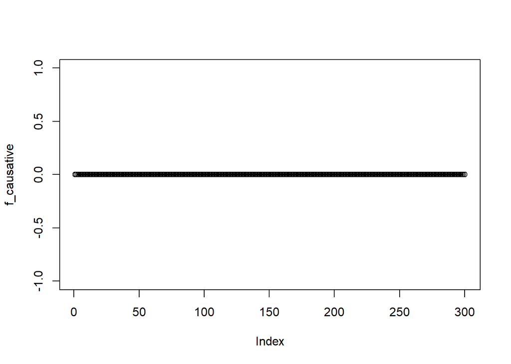

```r
## Plot the resulting frequency trajectory for illustration

plot(f_causative)
```

```r
#post_selection_generation <- selection_scenario_pop[[n_selection_sim_generations]]


post_selection_generation <- selection_scenario_pop

cat("Population before the selection scenario simulation:\n")
```

```
## Population before the selection scenario simulation:
```

```r
last_bottleneck_generation
```

```
## An object of class "Pop"
## Ploidy: 2
## Individuals: 50
## Chromosomes: 1
## Loci: 147485
## Traits: 0
```

```r
cat("\nPopulation after",n_selection_sim_generations,"generations of selection scenario simulation:\n")
```

```
##
## Population after 300 generations of selection scenario simulation:
```

```r
post_selection_generation
```

```
## An object of class "Pop"
## Ploidy: 2
## Individuals: 100
## Chromosomes: 1
## Loci: 147485
## Traits: 0
```

# 3. Preparing to export the data

## 3.1: Adding SNPs to the final generation ( SimParam$addSnpChip())

### 3.1.1 Single chromosome usage: Computing number of SNPs to assign to a chromosome

```r
# Sum up the chromosome lengths to get the autosome length
autosome_length <- sum(chromosome_lengths_mb)

# Number of SNP markers from the empirical dataset
# https://datadryad.org/stash/dataset/doi:10.5061/dryad.h44j0zpkf
num_snp_markers <- 78088

# Calculate average SNP-autosome density
average_snp_autosome_density <- num_snp_markers / autosome_length

# Calculate the number of SNP markers to choose for the specific chromosome
num_snp_markers_chr3 <- average_snp_autosome_density * chromosome_lengths_mb[chr_simulated]



# Output results
cat("autosome length:", autosome_length, "Mb\n")
```

```
## autosome length: 2298 Mb
```

```r
cat("Average SNP-autosome density:", average_snp_autosome_density, "SNPs/Mb\n")
```

```
## Average SNP-autosome density: 33.98085 SNPs/Mb
```

```r
cat("Number of SNP markers for", chr_simulated, ":", num_snp_markers_chr3, "SNPs\n")
```

```
## Number of SNP markers for chr3 : 3194.2 SNPs
```

```r
average_chr_SNP_density <- num_snp_markers / length(chromosome_lengths_mb)
cat(" Average Chr SNP density:", average_chr_SNP_density, "SNPs/Chr\n")
```

```
##  Average Chr SNP density: 2054.947 SNPs/Chr
```

### 3.1.2: SimParam$addSnpChip() - Randomly assigns eligible SNPs to a SNP chip

`SP$addSnpChip()`Randomly assigns eligible SNPs to a SNP chip.

**nSnpPerChr**-argument that assigns for each individuals n SNPs for each chromsome, where n is the user-specified number.

**minSnpFreq**-argument sets the Minimum Allele Frequency (MAF) allowed for each marker. For instance, setting minSnpFreq = 0.05 ensures that all markers will have MAF >= 0.05

```r
SP$addSnpChip(
  nSnpPerChr = num_snp_markers_chr3,
  minSnpFreq = min_MAF,
  refPop = post_selection_generation
  )
```

# 4: Export to PLINK Extracting data to PLINK

## 4.0.1: Optional: pullSnpGeno() - Retrieves a list of the existing marker id:s (SNP id:s)

Function that retrieves SNP genotype data & returns a matrix of SNP genotypes

## 4.0.2: Optional: getSnPMap() - Retrieves a table of the genetic map

Function that retrieves the genetic map for a given SNP chip & returns a data.frame with:

- **id:** Unique identifier for the marker (SNP)
- **chr:** Chromosome containing the SNP
- **site:** Segregating site on the chromosome
- **pos:** Genetic map position

```r
# SP$addSnpChip(5)
# getSnpMap(snpChip=1,simParam=SP)

#getSnpMap(simParam=SP)

cat("First 10 markers and their genetic map positions:\n")
```

```
## First 10 markers and their genetic map positions:
```

```r
kable(head(getSnpMap(simParam = SP), 10))
```

|  | id | chr | site | pos |
| --- | --- | --- | --- | --- |
| 1_39 | 1_39 | 1 | 39 | 0.0002308 |
| 1_57 | 1_57 | 1 | 57 | 0.0003580 |
| 1_71 | 1_71 | 1 | 71 | 0.0004482 |
| 1_75 | 1_75 | 1 | 75 | 0.0004808 |
| 1_186 | 1_186 | 1 | 186 | 0.0011044 |
| 1_199 | 1_199 | 1 | 199 | 0.0011543 |
| 1_253 | 1_253 | 1 | 253 | 0.0014439 |
| 1_363 | 1_363 | 1 | 363 | 0.0022139 |
| 1_374 | 1_374 | 1 | 374 | 0.0022986 |
| 1_385 | 1_385 | 1 | 385 | 0.0023611 |

```r
#head(getSnpMap(simParam = SP), 10)
```

## 4.1: writePlink()

**Description** Function that inputs a Pop-class & exports it to PLINK PED and MAP files.

The arguments for this function were chosen for consistency with RRBLUP2. **The base pair coordinate will the locus position as stored in AlphaSimR** & not an actual base pair position, because AlphaSimR doesn’t track base pair positions, **only relative positions for the loci used in the simulation**.

** Usage ** writePlink( pop, baseName, traits = 1, use = “pheno”, snpChip = 1, useQtl = FALSE, simParam = NULL, … )

**Arguments:**

- **pop** an object of Pop-class
- **baseName** basename for PED and MAP files.
- **traits** an integer indicating the trait to write, a trait name, or a function of the traits returning a single value.
- **use** what to use for PLINK’s phenotype field. Either phenotypes “pheno”, genetic values “gv”, estimated breeding values “ebv”, breeding values “bv”, or random values “rand”.
- **snpChip** an integer indicating which SNP chip genotype to use useQtl should QTL genotypes be used instead of a SNP chip.

  ```
     -    If TRUE, snpChip specifies which trait’s QTL to use, and thus these QTL may not match the QTL underlying the phenotype supplied in traits.
  ```

- **simParam** an object of SimParam … additional arguments if using a function for traits

```r
# Setting the directory where the .map and .ped files will be stored in
setwd(output_dir_simulation)

writePlink(post_selection_generation,simParam=SP, baseName=output_sim_files_basename,

            traits = 1,
           use = "rand"


           )
```

# 5: Convert distances to basepair in the .map file

```r
# Setting the working directory as the output directory
setwd(output_dir_simulation)

# Read PLINK files into R objects
ped_file <- paste0(output_sim_files_basename, '.ped')
map_file <- paste0(output_sim_files_basename, '.map')
ped_data <- read.table(ped_file)
map_data <- read.table(map_file)


genetic_distance_morgan_column <- map_data$V3 # Extracting the genetic distance column of map_data (3rd column)
base_pair_position_column <- round(genetic_distance_morgan_column * (model_chromosome_bp_length / 100))

# Redefining the physical position column (4th column) with the new values defined in base_pair_position_column
map_data$V4 <- base_pair_position_column

write.table(map_data, file = map_file, sep = "\t", row.names = FALSE, col.names = FALSE,quote = FALSE)

#col.names = FALSE: Removes the header.
#quote = FALSE: Removes quotation marks from values.


cat("Showing the first 10 rows of the new .map file:\n")
```

```
## Showing the first 10 rows of the new .map file:
```

```r
kable(head(map_data, 10))
```

| V1 | V2 | V3 | V4 |
| --- | --- | --- | --- |
| 1 | 1_39 | 0.0230793 | 21695 |
| 1 | 1_57 | 0.0358006 | 33653 |
| 1 | 1_71 | 0.0448247 | 42135 |
| 1 | 1_75 | 0.0480798 | 45195 |
| 1 | 1_186 | 0.1104412 | 103815 |
| 1 | 1_199 | 0.1154292 | 108503 |
| 1 | 1_253 | 0.1443923 | 135729 |
| 1 | 1_363 | 0.2213910 | 208108 |
| 1 | 1_374 | 0.2298602 | 216069 |
| 1 | 1_385 | 0.2361076 | 221941 |